# Maps in R: Exercises

These exercises accompany the Maps in R tutorial: http://rpubs.com/NateByers/Maps. These exercises use daily No<sub>2</sub> data for the United States in 2014. Run the following code to clean out your global environment and load the data you need:

```r
rm(list = ls())
library(dplyr)
library(region5air)
data(no2_2014)
```

If you are curious about where this data came from, see the Download section below.

## Exercises

1. Use `dplyr` to create a data frame called `no2_max`. It should be a filtered subset of the `no2_2014` data frame so that each monitor has one record with the highest 1-hour NO<sub>2</sub> maximum for the entire year. **Hint:** Take a look at the column names, `names(no2_2014)`. Use `group_by()` to group by state, county, and site. Use `filter()` to find which 1st-max-value is equal to the maximum of the 1st-max-value column (use `==`).

Solution 1

2. Make a map of NO<sub>2</sub> monitors. Use `map(database = 'usa')` to make a map of the US first. Then use `points()` to add the monitors from the `no2_max` data frame.

Solution 2

3. Use `filter()` to make a new data frame of NO<sub>2</sub> motors that had a 1 hour max value above 100 ppb. Call the new data frame `no2_violations` and map those monitors.

Solution 3

4. Use the `leaflet` package to make an interactive map of the monitors in the `no2_violations` data frame.

Solution 4

#### Advanced Exercise

5. Use the `choroplethr` package to make a heat map of the number of NO<sub>2</sub> monitors in each state. **Hint:** You will need to make a new data frame called `no2_monitors`. Start with the `no2_max` data frame and group by state. Use the `summarize()` function to get the total number of monitors in each group. The `n()` function will count the total number of rows in a group.

Solution 5

## Solutions

#### Solution 1

Here are the columns.

```r
names(no2_2014)
```

```
##  [1] "State.Code"          "County.Code"         "Site.Num"
##  [4] "Parameter.Code"      "POC"                 "Latitude"
##  [7] "Longitude"           "Datum"               "Parameter.Name"
## [10] "Sample.Duration"     "Pollutant.Standard"  "Date.Local"
## [13] "Units.of.Measure"    "Event.Type"          "Observation.Count"
## [16] "Observation.Percent" "Arithmetic.Mean"     "X1st.Max.Value"
## [19] "X1st.Max.Hour"       "AQI"                 "Method.Code"
## [22] "Method.Name"         "Local.Site.Name"     "Address"
## [25] "State.Name"          "County.Name"         "City.Name"
## [28] "CBSA.Name"           "Date.of.Last.Change"
```

Now we know the column names for state, county, and site. Let’s group by those columns.

```r
no2_max <- group_by(no2_2014, State.Name, County.Name, Site.Num)
```

Now we’ll filter the data frame so that the “X1st.Max.Value” is equivalent to the maximum for each group.

```r
no2_max <- filter(no2_max, X1st.Max.Value == max(X1st.Max.Value, na.rm = TRUE))
```

Back to exercises

#### Solution 2

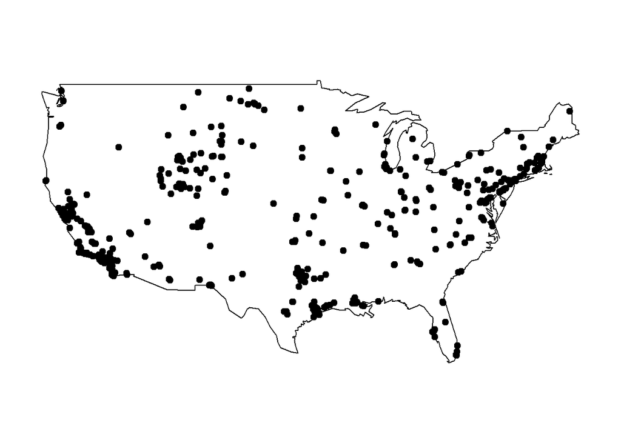

```r
library(maps)
map(database = 'usa')
points(x = no2_max$Longitude, y = no2_max$Latitude, pch = 19)
```

Back to exercises

#### Solution 3

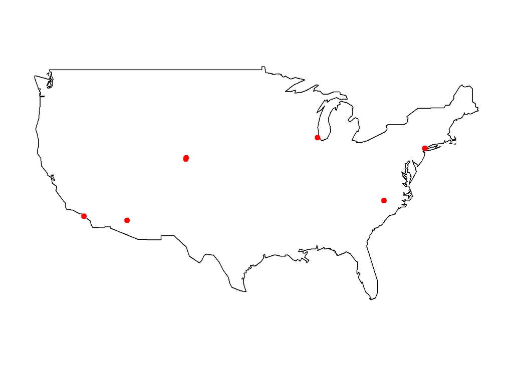

```r
no2_violations <- filter(no2_max, X1st.Max.Value > 100)
map(database = 'usa')
points(x = no2_violations$Longitude, y = no2_violations$Latitude, pch = 19,
       col = "red")
```

Back to exercises

#### Solution 4

```r
library(leaflet)
m <- leaflet()
m <- addTiles(m)
m <- addMarkers(m, lng=no2_violations$Longitude, lat=no2_violations$Latitude,
                popup=no2_violations$CBSA.Name)
m
```

[interactive chart not shown]

Back to exercises

#### Solution 5

```r
no2_monitors <- group_by(no2_max, State.Name)
no2_monitors <- summarize(no2_monitors, value = n())
```

The `choroplethr` package wants full state names with lower case. So we need to remove Puerto Rico, turn the state values to all lower case, and rename the state column to “region”

```r
no2_monitors <- filter(no2_monitors, State.Name != "Puerto Rico")
no2_monitors <- mutate(no2_monitors, State.Name = tolower(State.Name))
no2_monitors <- rename(no2_monitors, region = State.Name)
```

Now we can make the map.

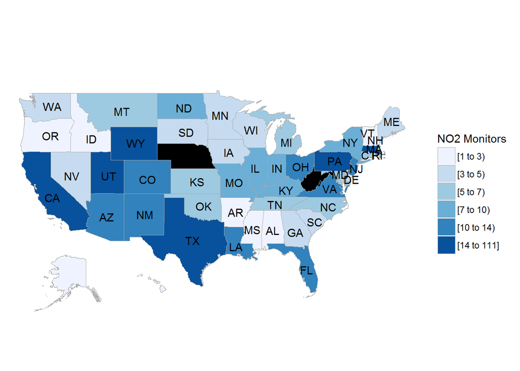

```r
library(choroplethr)
no2_map <- state_choropleth(no2_monitors, legend = "NO2 Monitors")
no2_map
```

Just for fun, let’s see that with pipes.

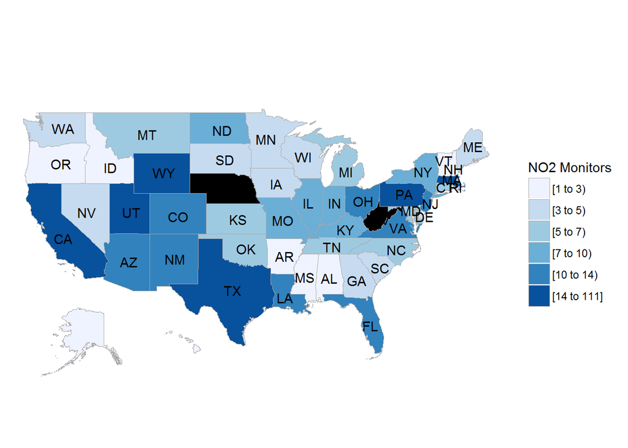

```r
no2_map_piped <- no2_max %>%
  group_by(State.Name) %>%
  summarize(value = n()) %>%
  filter(State.Name != "Puerto Rico") %>%
  mutate(State.Name = tolower(State.Name)) %>%
  rename(region = State.Name) %>%
  state_choropleth(legend = "NO2 Monitors")

no2_map_piped
```

Back to exercises

## Download

Below is the code for retrieving the `no2_2014` data frame from the [EPA website](http://aqsdr1.epa.gov/aqsweb/aqstmp/airdata/download_files.html).

```r
# create a temporary file
temp <- tempfile()

# download the .zip file to a temporary file--this might take a minute or two
download.file('http://aqsdr1.epa.gov/aqsweb/aqstmp/airdata/daily_42602_2014.zip', temp)

# read the .csv file into R
no2 <- read.csv(unz(temp, 'daily_42602_2014.csv'), stringsAsFactors = FALSE)

# delete the temporary file
unlink(temp)
```